# 20251209_tscan_trajectories

Stephanie Hickey

2025-12-11

#### Lab: Weiming Li

#### Project: BCC125_sea_lamprey_scRNA

```r
# Load libraries
library(tidyverse)
library(dplyr)
library(ggplot2)
library(SingleCellExperiment)
library(scater)
library(scran)
library(patchwork)
library(pheatmap)
library(RColorBrewer)
library(readxl)
library(monocle3)
library(batchelor)
library(BiocSingular)
library(DT)
library(TSCAN)
library(rtracklayer)
source(paste0(params$project_dir, "/src/scRNA_seq_functions.R"))
```

```r
# Set Paths
results_dir = paste0(params$project_dir, "/results/20251203")
# results_dir = "/mnt/ufs18/rs-013/bioinformaticsCore/projects/chong_davidson/BCC125_sea_lamprey_scRNA/results/20251203"
data_dir = paste0(params$project_dir, "/data")
# data_dir = "/mnt/ufs18/rs-013/bioinformaticsCore/projects/chong_davidson/BCC125_sea_lamprey_scRNA/data"
```

# Collect individual samples into one object

```r
# Load QC'd data
sample_dirs = list.dirs(data_dir, full.names = TRUE, recursive = FALSE)
sample_names = basename(sample_dirs)

cds_list = list()

for(i in 1:length(sample_dirs)){

  cds_list[[i]] = readRDS(paste0(sample_dirs[i],
                                 "/",
                                 sample_names[i],
                                 "_cds_mito_filter.Rds"))
}

names(cds_list) = sample_names
all.sce = list()

# cds to sce
for (cds in names(cds_list)){

  raw_counts = counts(cds_list[[cds]])
  all.sce[[cds]] =
    SingleCellExperiment(list(counts=raw_counts),
                         colData=cds_list[[cds]]@colData)
  all.sce[[cds]]@colData$sample = cds

}

# https://bioconductor.org/books/3.14/OSCA.multisample/human-pbmcs-10x-genomics.html
# normalization, feature selection, dim reduction
all.sce <- lapply(all.sce, logNormCounts)
all.dec <- lapply(all.sce, modelGeneVar)
all.hvgs <- lapply(all.dec, getTopHVGs, prop=0.1)
all.sce <- mapply(FUN=runPCA, x=all.sce, subset_row=all.hvgs)

saveRDS(all.sce, file=paste0(results_dir, "/all.sce.Rds"))
```

# Make info per sample table

```r
df_list = list()

for(samp in names(all.sce)){

  # number of cells
  ncells = ncol(all.sce[[samp]])
  # mean counts
  med_counts = round(median(colData(all.sce[[samp]])$sum))
  # mean genes detected
  med_genes = round(median(colData(all.sce[[samp]])$detected))
  # mean percent mitochondria
  med_mito = median(colData(all.sce[[samp]])$subsets_Mito_percent)
  med_mito = round(med_mito, digits = 2)

  df_list[[samp]] =
    data.frame(Sample = samp,
              nCells = ncells,
              medianCounts = med_counts,
              medianGenesDetected = med_genes,
              medianPercentMitoReads = med_mito
              )
}

df_all = do.call(rbind,df_list)
write.csv(df_all, file = paste0(results_dir, "/median_stats.csv"))

datatable(df_all, rownames = FALSE)
```

| Sample | nCells | medianCounts | medianGenesDetected | medianPercentMitoReads |
| --- | --- | --- | --- | --- |
| TF_C00004337 | 13803 | 6066 | 1287 | 0.67 |
| TM_C00004374 | 18324 | 10532 | 2141 | 2.19 |
| UND1_C00004336 | 17186 | 5721 | 1366 | 1.3 |
| UND2_C00004362 | 17454 | 6396 | 1431 | 1.29 |

# Merge samples, removing sample batch effect

```r
# integration
# Intersecting the common genes.
universe <- Reduce(intersect, lapply(all.sce, rownames))
all.sce2 <- lapply(all.sce, "[", i=universe,)
all.dec2 <- lapply(all.dec, "[", i=universe,)

# Renormalizing to adjust for differences in depth.
normed.sce <- do.call(multiBatchNorm, all.sce2)

# Identifying a set of HVGs using stats from all batches.
combined.dec <- do.call(combineVar, all.dec2)
combined.hvg <- getTopHVGs(combined.dec, n=5000)

set.seed(1)
merged.sce <- do.call(fastMNN, c(normed.sce,
    list(subset.row=combined.hvg, BSPARAM=RandomParam())))

# clustering in corrected space
g <- buildSNNGraph(merged.sce, use.dimred="corrected", k=30)
set.seed(1)
colLabels(merged.sce) <- factor(igraph::cluster_louvain(g)$membership)

set.seed(1)
merged.sce <- runUMAP(merged.sce, dimred="corrected")
set.seed(1)
merged.sce <- runTSNE(merged.sce, dimred="corrected")

saveRDS(merged.sce, file = paste0(results_dir, "/merged.sce.Rds"))
```

The plot below shows the merged data in TSNE space separated by sample.

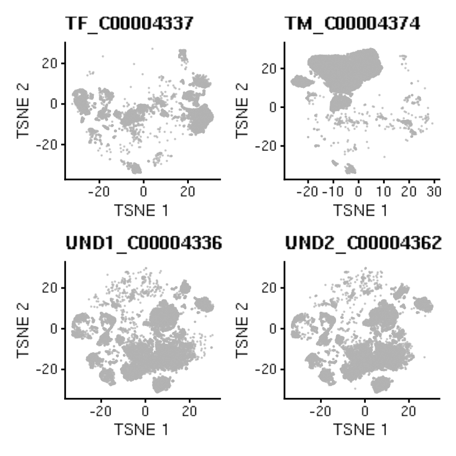

```r
# plot TSNE

p <- lapply(unique(merged.sce$batch), function(f) {
  sce.f = merged.sce[, which(merged.sce$batch == f)]
  plotTSNE(sce.f, point_size = .05) + ggtitle(f)
})

wrap_plots(p, ncol = 2)
```

This plot shows clusters identified using the “scatter” package in the batch corrected expression space.

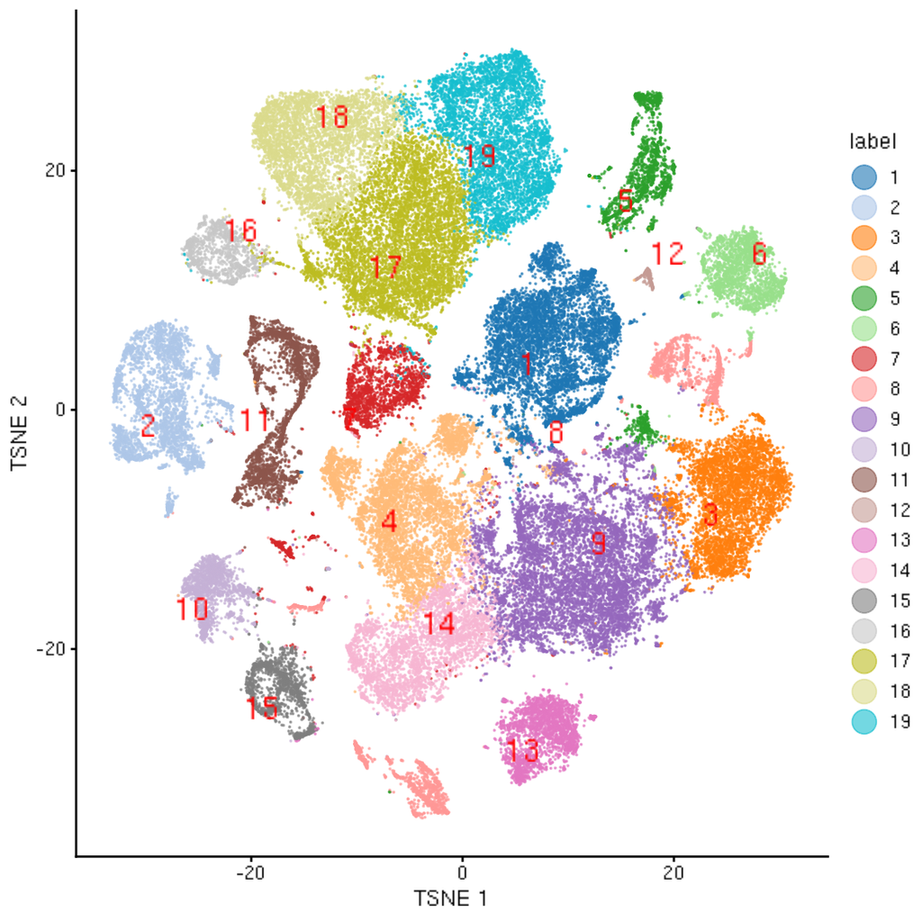

```r
plotTSNE(merged.sce, colour_by="label", text_by="label", text_colour="red", point_size = .05) +
  guides(color = guide_legend(override.aes = list(size=5)))
```

```r
#ggsave(file = paste0(results_dir, "/all_cells_tsne.png"))
```

This plot shows the proportion of cells from each sample within each new cluster.

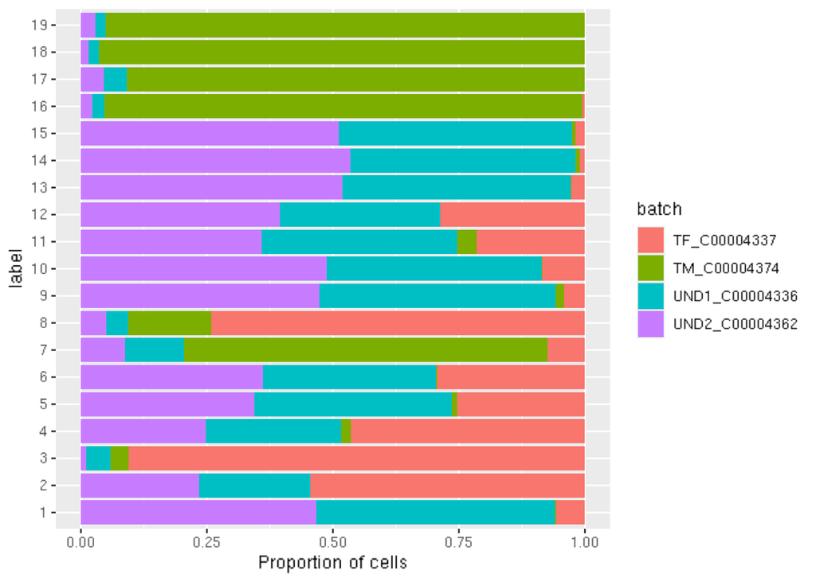

```r
meta_df = as.data.frame(colData(merged.sce))

sample_tally =
  meta_df %>%
  group_by(label, batch) %>%
  tally()

ggplot(sample_tally, aes(fill=batch, y=label, x=n)) +
    geom_bar(position="fill", stat="identity") +
    xlab("Proportion of cells")
```

```r
# make cds for plotting with monocle
# Intersecting the common genes.
all.dec <- lapply(all.sce, modelGeneVar)
universe <- Reduce(intersect, lapply(all.sce, rownames))
all.sce2 <- lapply(all.sce, "[", i=universe,)
all.dec2 <- lapply(all.dec, "[", i=universe,)

all.sce2[["TM_C00004374"]]@colData$cluster="noclust"

# uncorrected gene expression
combined.sce <- do.call(cbind, all.sce2)
saveRDS(combined.sce, file = paste0(results_dir, "/combined.sce.Rds"))

merged.cds <- new_cell_data_set(counts(combined.sce),
                                cell_metadata = merged.sce@colData)

reducedDims(merged.cds)$UMAP <- reducedDims(merged.sce)$UMAP
reducedDims(merged.cds)$tSNE <- reducedDims(merged.sce)$TSNE
rowData(merged.cds)$gene_short_name = row.names(merged.cds)

# saveRDS(merged.cds, file = paste0(results_dir, "/merged.cds.Rds"))
```

## Gene descriptions from Wang et al. and the kPetMar1.pri gtf

Summarized from [Wang et al, 2024](https://www.nature.com/articles/s41467-024-55019-x#Sec16):

The sea lamprey reference genome has over 60% of genes labeled with generic “LOC” numbers, meaning their functions are unknown. To enable proper cell type identification using known retina markers, the researchers re-annotated these genes by finding their human equivalents through the following process: Method:

1. Converted LOC IDs to protein sequences
2. Used BLAST to find matching human proteins
3. Assigned human gene symbols to lamprey genes with human matches (written in UPPERCASE)
4. For genes without human matches, searched other species (written in lowercase)
5. Added suffixes to distinguish genes encoding the same protein

```r
library(readxl)
# https://static-content.springer.com/esm/art%3A10.1038%2Fs41467-024-55019-x/MediaObjects/41467_2024_55019_MOESM3_ESM.xlsx
gene_description =
  read_excel(paste0(data_dir, "/41467_2024_55019_MOESM3_ESM.xlsx"), skip=1) %>%
  dplyr::rename(WangGeneID = "CountMatrix_GeneID",
                Gene = "NCBI_GTF_GENEID",
                description = "NCBI_GTF_ProteinInfo") %>%
  dplyr::select(Gene,WangGeneID,description) %>%
  filter(!is.na(Gene)) %>%
  filter(!WangGeneID %in% c("LOC116945425.1", "S100A1.1")) # loc has two wang ids


gtf = as.data.frame(readGFF("/mnt/research/bioinformaticsCore/shared/Genomes/Petromyzon_marinus/GCF_010993605.1_kPetMar1.pri_genomic.gtf"))

gtf_filt =
  gtf %>%
  filter(gbkey %in% c("mRNA", "misc_RNA", "ncRNA", "tRNA", "rRNA")) %>%
  mutate(product = gsub(", transcript variant.*", "", product)) %>%
  select(gene_id, product) %>%
  distinct() %>%
  dplyr::rename(Gene = "gene_id",
                description = "product") %>%
  mutate(WangGeneID = Gene)


notWang = gtf_filt$Gene[!gtf_filt$Gene %in% gene_description$Gene]

gtf_add =
  gtf_filt %>%
  filter(Gene %in% notWang)

gene_description =
  rbind(gene_description, gtf_add)

write.csv(gene_description, file = paste0(results_dir, "/gene_descritption.csv"), row.names = F)

datatable(gene_description)
```

|  | Gene | WangGeneID | description |
| --- | --- | --- | --- |
| 1 | A2ML1 | A2ML1 | alpha-2-macroglobulin like 1 |
| 2 | AAAS | AAAS | aladin WD repeat nucleoporin, transcript variant X1 |
| 3 | AACS | AACS | model_evidence Supporting evidence includes similarity to: 4 ESTs, 10 Proteins, and 99% coverage of the annotated genomic feature by RNAseq alignments, including 49 samples with support for all annota… |
| 4 | LOC116938545 | aad-a | alpha-aspartyl dipeptidase-like |
| 5 | AADAT | AADAT | aminoadipate aminotransferase |
| 6 | AAGAB | AAGAB | alpha and gamma adaptin binding protein |
| 7 | AAMDC | AAMDC | adipogenesis associated Mth938 domain containing, transcript variant X1 |
| 8 | AAMP | AAMP | angio associated migratory cell protein, transcript variant X2 |
| 9 | AANAT | AANAT | aralkylamine N-acetyltransferase |
| 10 | AAR2 | AAR2 | AAR2 splicing factor, transcript variant X5 |

[output cut: 21957 more lines]

## Load known cell-type markers

```r
# load known marker genes
library(readr)
markers_wide = read.csv(paste0(data_dir, "/Cell_Type_Marker_Genes_12-9-25.csv"))
markers_wide = markers_wide[,2:ncol(markers_wide)]

markers_long <- markers_wide %>%
  pivot_longer(
    cols = everything(),
    names_to = "CellType",
    values_to = "Gene",
    values_drop_na = TRUE
  ) %>%  mutate(
    main_part = str_remove(Gene, "\\s*\\(.*\\)"),  # Remove parentheses and content
    paren_part = str_extract(Gene, "(?<=\\().*(?=\\))")  # Extract content inside parentheses
  ) %>%
  tidyr::separate_rows(main_part, sep = "/") %>%
  mutate(main_part = trimws(main_part),
         paren_part = trimws(paren_part))

chung_davidson_markers = markers_long %>%
  select(CellType, main_part) %>%
  dplyr::rename(WangGeneID = "main_part") %>%
  filter(!WangGeneID == "") %>%
  left_join(gene_description) %>%
  filter(!is.na(Gene))

datatable(chung_davidson_markers %>% arrange(CellType), rownames = F)
```

| CellType | WangGeneID | Gene | description |
| --- | --- | --- | --- |
| Endothelial.cells | CAV1 | CAV1 | caveolin 1 |
| Endothelial.cells | NOSTRIN | LOC116938778 | nostrin-like |
| Endothelial.cells | PALMD | PALMD | palmdelphin |
| Endothelial.cells | SOX18 | LOC116941541 | transcription factor Sox-18-like |
| Endothelial.cells | SOX7 | SOX7 | SRY-box transcription factor 7 |
| Endothelial.cells | FLT1-1 | LOC116955055 | vascular endothelial growth factor receptor 1-like, transcript variant X1 |
| Endothelial.cells | VWF | VWF | von Willebrand factor |
| Erythrocytes | globin-1 | LOC116951579 | globin-1 |
| Erythrocytes | globin-2 | LOC116951663 | globin-2 |
| Erythrocytes | globin-3 | LOC116951566 | globin-3 |

[output cut: 53 more lines]

## Compare scatter cluster enriched genes with known markers

### Cluster enriched genes

This table contains the top ~100 cluster enriched genes for each cluster. All of the cluster enriched genes are saved in `results/scatter_cluster_marker_genes.csv`. The markers can help us map a cluster to a cell type.

In this case, genes in each cluster were compared to genes in every other cluster in a pairwise manner, and the p.values and logFCs of those comparisons have been summarized for ease of interpretation.

**Column descriptions**

- `cluster`: The cluster corresponding to the enriched genes.
- `Gene`: The enriched gene
- `p.value`: The combined p-value across all pairwise comparisons.
- `FDR`: The BH-adjusted p-value for each gene.
- `summary.logFC`: This contains the summary effect size, obtained by combining effect sizes from all pairwise comparison into a single value.

```r
scatter_markers = findMarkers(combined.sce,
                              merged.sce$label,
                              test.type="t",
                              block=combined.sce$sample,
                              direction="up",
                              pval.type="some")

saveRDS(scatter_markers, file= paste0(results_dir, "/scatter_markers.Rds"))

scatter_summary = list()

for (i in 1:length(scatter_markers)){

scatter_markers[[i]]$cluster = i
scatter_markers[[i]]$Gene = rownames(scatter_markers[[i]])
scatter_summary[[i]] =
  as.data.frame(scatter_markers[[i]]) %>%
  select(cluster, Gene, p.value, FDR, summary.logFC)

}

scatter_markers_df =
  do.call(rbind, scatter_summary) %>%
  left_join(gene_description, by="Gene") %>%
  filter(FDR < .01)

write.csv(scatter_markers_df, file = paste0(results_dir, "/scatter_cluster_marker_genes.csv"))

scatter_markers_top100 =
  scatter_markers_df %>%
  group_by(cluster) %>%
  slice_min(FDR, n = 100, with_ties=TRUE)

datatable(scatter_markers_top100, filter = "top", rownames = FALSE)
```

| cluster | Gene | p.value | FDR | summary.logFC | WangGeneID | description |
| --- | --- | --- | --- | --- | --- | --- |
| 1 | COL6A2 | 0 | 0 | 3.33275092054236 | COL6A2 | collagen type VI alpha 2 chain, transcript variant X1 |
| 1 | LOC116938842 | 0 | 0 | 2.898349211427449 | COL6A3 | collagen alpha-3(VI) chain-like |
| 1 | LOC116955666 | 0 | 0 | 2.530407483901493 | LOC116955666 | uncharacterized LOC116955666, transcript variant X3 |
| 1 | COL6A1 | 0 | 0 | 4.322101251117065 | COL6A1 | collagen type VI alpha 1 chain |
| 1 | LOC116948593 | 0 | 0 | 5.229058772064612 | COL2A1.2 | collagen alpha-1(II) chain-like |
| 1 | LOC103091741 | 0 | 0 | 3.908177179896214 | BGN.1 | biglycan, transcript variant X1 |
| 1 | SPARC | 0 | 0 | 5.732851647684042 | SPARC | secreted protein acidic and cysteine rich, transcript variant X1 |
| 1 | LOC116952696 | 0 | 0 | 2.307083853409585 | KERA.1 | keratocan-like |
| 1 | LOC116938527 | 0 | 0 | 6.214137595158199 | COL2A1 | collagen alpha-1(II) chain-like |
| 1 | LOC116942816 | 0 | 0 | 3.083295609607938 | LECT2.1 | leukocyte cell-derived chemotaxin-2-like, transcript variant X1 |

[output cut: 2058 more lines]

### Comparison with known markers

We’ll check for the significance of the overlap between the top 100 cluster enriched genes and the supplied known cell-type markers. In the plot below, the rows represent cell types with know marker genes, and the columns represent the cell clusters. The number in each box is the number of genes shared between the top 100 cluster enriched genes for the specified clusters and the specified known cell-type markers. Each box is colored by the significance of the overlap ($-log10(FDR)$). Significant overlaps may signify that the cells in the cluster belong to the specified cell type.

- Overlap p-values are save in `results/scatter_cluster_marker_overlap_pvalues.csv`.
- Overlaps between cluster enriched genes and known marker genes are save in `results/scatter_cluster_marker_gene_overlaps.csv`.

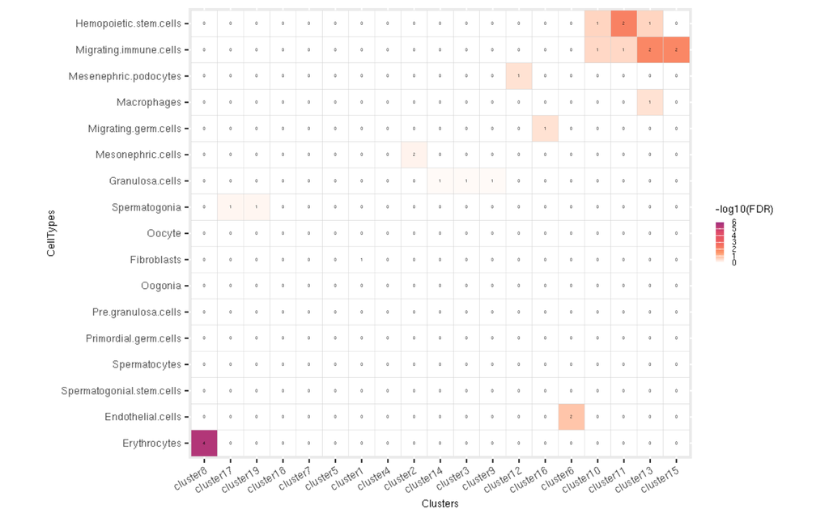

```r
marker_test_genes =
  scatter_markers_top100 %>%
  select(Gene, cluster) %>%
  mutate(cluster = paste0("cluster", cluster))

chung_davidson_cell_type_markers =
chung_davidson_markers %>%
  select(Gene, CellType)

cluster_ol =  phyperOverlapSets(chung_davidson_cell_type_markers,
                                marker_test_genes, length(merged.sce))

shared_gene_description =
  gene_description %>%
  rename(Gene = "SharedGene")

cluster_ol$intersecting.genes =
  cluster_ol$intersecting.genes %>%
  left_join(shared_gene_description, by="SharedGene")

write.csv(cluster_ol$intersecting.genes, file = paste0(results_dir, "/scatter_cluster_marker_gene_overlaps.csv"), row.names = FALSE)

scores = cluster_ol$pval.scores

scores =
  scores %>%
  rename(Group1 = "CellTypes",
         Group2 = "Clusters") %>%
  group_by(CellTypes) %>%
    mutate(FDR = p.adjust(Pval, "BH"))

write.csv(scores, file = paste0(results_dir, "/scatter_cluster_marker_overlap_pvalues.csv"), row.names = FALSE)

#scores$FDR[scores$FDR > .01] = 1

FDR_wide <-
  scores %>%
  mutate(logFDR = -log10(FDR)) %>%
  tidyr::pivot_wider(id_cols = CellTypes,
                     names_from = Clusters,
                     values_from=logFDR)

CellTypes = FDR_wide$CellTypes
FDR_wide$CellTypes = NULL

FDR_wide = as.matrix(FDR_wide)
rownames(FDR_wide) = CellTypes

ord_row <- hclust( dist(FDR_wide), method = "ward.D" )$order
ord_col <- hclust( dist(t(FDR_wide)), method = "ward.D" )$order

scores$CellTypes = factor(scores$CellTypes, levels = rownames(FDR_wide)[ord_row])
scores$Clusters = factor(scores$Clusters, levels = colnames(FDR_wide)[ord_col])

plot1 =
    ggplot(scores,
           aes(Clusters, CellTypes)) +
           geom_tile(aes(fill = -log10(FDR)),
                     color = "light gray") +
        #Creating legend
        guides(fill=guide_colorbar(title = "-log10(FDR)",
                                   barheight = 10,
                                   barwidth = 2,
                                   default.unit = "mm")) +
        #Creating color range
        scale_fill_gradientn(colors=c("white",
                                      "#fd9668",
                                      "#f1605d",
                                      "#de4968",
                                      "#9e2f7f"),
                             guide="colorbar",
                             limits = c(0, ceiling(-log10(min(scores$FDR))))
                             ) +
        #Rotating labels
         theme(axis.text.x = element_text(angle = 30,
                                          hjust = 1,vjust=1),
               ) +
        theme(text = element_text(size = 7),
              axis.text = element_text(size = 7)) +
        geom_text(aes(label = nSharedGenes), size = 1) +
        coord_fixed()

plot1
```

```r
ggsave(plot1, file = paste0(results_dir, "/scatter_cluster_overlap_heatmap.png"))
```

## Gene ontology of top 100 scatter cluster enriched genes

To help annotate cell type clusters, we can check for enriched gene ontology categories among cell-type enriched genes.

**Columns**

- `GOID`: Gene ontology ID
- `GOName`: Gene ontology name
- `nGOTermGenes`: Number of genes assigned to GO term
- `Clusters`: Cluster
- `nClusterEnrichedGenes`: Number of cluster enriched genes
- `nSharedGenes`: Number of shared genes between the GO term and cluster enriched genes
- `Pval`: p-value
- `FDR`: p-value corrected for multiple comparisons

Overlap p-values are save in `results/scatter_cluster_marker_gene_GO_overlap_pvalues.csv`. Overlaps between cluster enriched genes and known marker genes are save in `results/scatter_cluster_marker_gene_GO_overlaps.csv`.

```r
gaf = read.delim("/mnt/research/bioinformaticsCore/shared/Genomes/Petromyzon_marinus/GCF_010993605.1_kPetMar1.pri_gene_ontology.gaf", header=F, comment = "!")

gaf <-
  gaf %>%
  filter(!grepl("NOT", V4)) %>%
  dplyr::select(V3, V5) %>%
  dplyr::rename(GOID = "V5",
                Gene = "V3") %>%
  distinct()

keep_go =
  gaf %>%
  group_by(GOID) %>%
  tally() %>%
  filter(n > 10,
         n < 200) %>%
  pull(GOID)

gaf =
  gaf %>%
  filter(GOID %in% keep_go)

go_names = read.delim("/mnt/research/bioinformaticsCore/shared/Genomes/Petromyzon_marinus/GOs_names.txt", header = F)
colnames(go_names) = c("GOID", "GOName")

go_ol =  phyperOverlapSets(gaf,
                           marker_test_genes, length(merged.cds))

shared_gene_description =
  gene_description %>%
  rename(Gene = "SharedGene")

go_ol$intersecting.genes =
  go_ol$intersecting.genes %>%
  left_join(shared_gene_description, by="SharedGene")

write.csv(go_ol$intersecting.genes, file = paste0(results_dir, "/scatter_cluster_marker_gene_GO_overlaps.csv"), row.names = FALSE)

scores = go_ol$pval.scores

scores =
  scores %>%
  dplyr::rename(GOID = "Group1",
                Clusters = "Group2",
                nGOTermGenes = "nGroup1",
                nClusterEnrichedGenes = "nGroup2") %>%
  group_by(Clusters) %>%
    mutate(FDR = p.adjust(Pval, "BH")) %>%
  select(-Enrichment)

scores =
  left_join(go_names, scores, by="GOID") %>%
  filter(!is.na(nGOTermGenes)) %>%
  filter(Pval < .01)

write.csv(scores, file = paste0(results_dir, "/scatter_cluster_marker_gene_GO_overlap_pvalues.csv"), row.names = FALSE)

datatable(scores, filter = "top", rownames = FALSE)
```

| GOID | GOName | nGOTermGenes | Clusters | nClusterEnrichedGenes | nSharedGenes | Pval | FDR |
| --- | --- | --- | --- | --- | --- | --- | --- |
| GO:0000027 | ribosomal large subunit assembly | 16 | cluster10 | 100 | 2 | 0.002361690308546165 | 0.1670895893296412 |
| GO:0000027 | ribosomal large subunit assembly | 16 | cluster13 | 100 | 2 | 0.002361690308546165 | 0.1670895893296412 |
| GO:0000028 | ribosomal small subunit assembly | 15 | cluster10 | 100 | 7 | 2.043744351559303e-13 | 2.478769934962641e-11 |
| GO:0000028 | ribosomal small subunit assembly | 15 | cluster13 | 100 | 4 | 5.309774988960386e-07 | 6.439998522324811e-05 |
| GO:0000028 | ribosomal small subunit assembly | 15 | cluster18 | 100 | 4 | 5.309774988960386e-07 | 6.439998522324811e-05 |
| GO:0000079 | regulation of cyclin-dependent protein serine/threonine kinase activity | 25 | cluster14 | 100 | 2 | 0.005748986011303322 | 0.1877265047537123 |
| GO:0000079 | regulation of cyclin-dependent protein serine/threonine kinase activity | 25 | cluster15 | 100 | 2 | 0.005748986011303322 | 0.2324232915998343 |
| GO:0000079 | regulation of cyclin-dependent protein serine/threonine kinase activity | 25 | cluster16 | 100 | 2 | 0.005748986011303322 | 0.1952355649438608 |
| GO:0000226 | microtubule cytoskeleton organization | 71 | cluster14 | 100 | 7 | 3.431368993290293e-08 | 9.71077425101153e-06 |
| GO:0000226 | microtubule cytoskeleton organization | 71 | cluster15 | 100 | 5 | 1.813717915325596e-05 | 0.002074390397409099 |

[output cut: 158 more lines]

## Annotations

| cluster | annotation |
| --- | --- |
| 1 | Fibroblasts |
| 2 | Mesonephric cells |
| 3 | Pre-granulosa cells I |
| 4 | Granulosa cells |
| 5 | PGCs/Oogonia/Oocytes |
| 6 | Endothelial cells |
| 7 | Migrating PGCs |
| 8 | Erythrocytes |
| 9 | Pre-granulosa cells II |
| 10 | Leukocytes |
| 11 | Hemopoietic stem cells |
| 12 | Podocytes |
| 13 | Macrophages |
| 14 | Pre-granulosa cells III |
| 15 | Migrating immune cells |
| 16 | Spermatogonia stem cells |
| 17 | Spermatogonia A |
| 18 | Spermatocyte |
| 19 | Spermatogonia B |

# Sex cell clusters analysis

Filter for cells in clusters 16, 17, 18, 19, 5, 7

| sex clusters | annotation |
| --- | --- |
| 7 | Migrating male germ cells |
| 5 | Primordial germ cells |
| 16 | Spermatogonia stem cells |
| 17 | Spermatogonia A |
| 18 | Spermatocyte |
| 19 | Spermatogonia B |

```r
# Load QC'd data
sample_dirs = list.dirs(data_dir, full.names = TRUE, recursive = FALSE)
sample_names = basename(sample_dirs)

cds_list = list()

for(i in 1:length(sample_dirs)){

  cds_list[[i]] = readRDS(paste0(sample_dirs[i],
                                 "/",
                                 sample_names[i],
                                 "_cds_mito_filter.Rds"))
}

names(cds_list) = sample_names

meta_df = as.data.frame(colData(merged.sce))
meta_df$cells = rownames(meta_df)

all.sex.sce = list()

# cds to sce
for (cds in names(cds_list)){

  raw_counts = counts(cds_list[[cds]])

  all.sce =
    SingleCellExperiment(list(counts=raw_counts),
                         colData=cds_list[[cds]]@colData)

  all.sce@colData$sample = cds

  sex.cells =
   meta_df %>%
   filter(label %in% c(16, 17, 18, 19, 5, 7),
          batch == cds) %>%
   pull(cells)

  all.sex.sce[[cds]] = all.sce[,sex.cells]
}

# https://bioconductor.org/books/3.14/OSCA.multisample/human-pbmcs-10x-genomics.html
# normalization, feature selection, dim reduction
set.seed(1)
all.sex.sce <- lapply(all.sex.sce, logNormCounts)
all.sex.dec <- lapply(all.sex.sce, modelGeneVar)
all.sex.hvgs <- lapply(all.sex.dec, getTopHVGs, prop=0.1)
all.sex.sce <- mapply(FUN=runPCA, x=all.sex.sce, subset_row=all.sex.hvgs)

saveRDS(all.sex.sce, file = paste0(results_dir, "/no.support.sex.sce.Rds"))
```

```r
all.sex.dec <- lapply(all.sex.sce, modelGeneVar)

# integration
# Intersecting the common genes.
universe <- Reduce(intersect, lapply(all.sex.sce, rownames))
all.sex.sce2 <- lapply(all.sex.sce, "[", i=universe,)
all.sex.dec2 <- lapply(all.sex.dec, "[", i=universe,)

# Renormalizing to adjust for differences in depth.
normed.sce <- do.call(multiBatchNorm, all.sex.sce2)

# Identifying a set of HVGs using stats from all batches.
combined.dec <- do.call(combineVar, all.sex.dec2)
combined.hvg <- getTopHVGs(combined.dec, n=5000)
```

```r
set.seed(1)
merged.sex.sce <- do.call(fastMNN, c(normed.sce,
    list(subset.row=combined.hvg, BSPARAM=RandomParam())))

# clustering in corrected space
set.seed(1)
#g <- buildSNNGraph(merged.sex.sce, use.dimred="corrected", k = 8)
g <- buildSNNGraph(merged.sex.sce, use.dimred="corrected", k = 20)
set.seed(1)
colLabels(merged.sex.sce) <- factor(igraph::cluster_louvain(g)$membership)

# add all cells scatter clusters
all.scatter.clust =
  meta_df %>%
  filter(label %in% c(16, 17, 18, 19, 5, 7)) %>%
  select(cells, label) %>%
  tibble::deframe()

all.scatter.clust <- all.scatter.clust[colnames(merged.sex.sce)]
merged.sex.sce$all.scatter.clust = all.scatter.clust

merged.sex.sce <- runUMAP(merged.sex.sce, dimred="corrected")
merged.sex.sce <- runTSNE(merged.sex.sce, dimred="corrected")

saveRDS(merged.sex.sce, file = paste0(results_dir, "/no.support.merged.sex.sce.Rds"))
```

## Plot new clusters in TSNE space

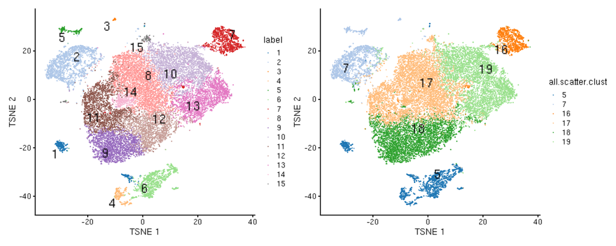

```r
tsne_new = plotTSNE(merged.sex.sce, colour_by="label", text_by="label", text_colour="black", point_size = .05)
tsne_old = plotTSNE(merged.sex.sce, colour_by="all.scatter.clust", text_by="all.scatter.clust", text_colour="black", point_size = .05)
tsne_new + tsne_old
```

### Table of original to new cluster assignment

Below is a table showing how many cells from each original sex cell cluster went to each new sex cell cluster.

```r
df <- as.data.frame(merged.sex.sce@colData)

df_count <-
  df %>%
  select(label, all.scatter.clust) %>%
  dplyr::rename(sex.merged.clusters = "label") %>%
  dplyr::count(sex.merged.clusters, all.scatter.clust) %>%
  group_by(all.scatter.clust) %>%
  mutate(total_m1 = sum(n)) %>%
  ungroup() %>%
  group_by(sex.merged.clusters) %>%
  mutate(total_m2 = sum(n)) %>%
  ungroup() %>%
  # Compute the percentage of total in method 1 and method 2
  mutate(
    pct_of_all.clusters = round((n / total_m1) * 100, 2),
    pct_of_sex.clusters = round((n / total_m2) * 100, 2)) %>%
  select(-total_m1, -total_m2)

datatable(df_count, filter = "top", rownames = FALSE)
```

| sex.merged.clusters | all.scatter.clust | n | pct_of_all.clusters | pct_of_sex.clusters |
| --- | --- | --- | --- | --- |
| 1 | 5 | 418 | 20.31 | 99.29 |
| 1 | 7 | 1 | 0.04 | 0.24 |
| 1 | 17 | 1 | 0.02 | 0.24 |
| 1 | 19 | 1 | 0.02 | 0.24 |
| 2 | 5 | 4 | 0.19 | 0.19 |
| 2 | 7 | 1885 | 84.26 | 91.86 |
| 2 | 16 | 1 | 0.09 | 0.05 |
| 2 | 17 | 56 | 0.86 | 2.73 |
| 2 | 18 | 23 | 0.56 | 1.12 |
| 2 | 19 | 83 | 1.67 | 4.04 |

[output cut: 47 more lines]

### Sex subclusters mapping to cluster annotations

| sex subclusters | annotation |
| --- | --- |
| 1 | PGCs/Oogonia/Oocytes |
| 2 | Migrating PGCs |
| 3 | Migrating PGCs |
| 4 | PGCs/Oogonia/Oocytes |
| 5 | Migrating PGCs |
| 6 | PGCs/Oogonia/Oocytes |
| 7 | Spermatogonia stem cells |
| 8 | Spermatogonia A |
| 9 | Spermatocyte |
| 10 | Spermatogonia B |
| 11 | Spermatogonia A/Spermatocyte |
| 12 | Spermatogonia A/Spermatocyte |
| 13 | Spermatogonia B |
| 14 | Spermatogonia A |
| 15 | Spermatogonia/Spermatocyte |

## Split by sample

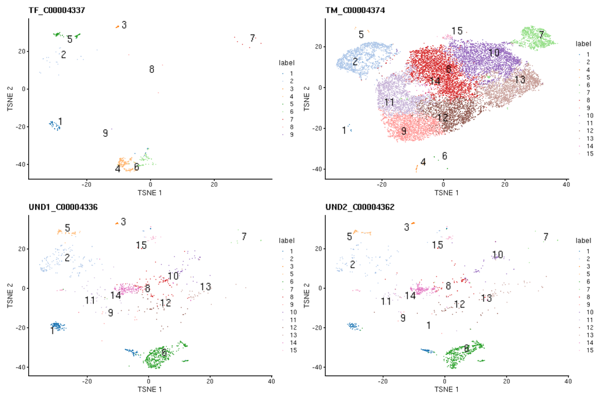

```r
# plot TSNE

p <- lapply(unique(merged.sex.sce$batch), function(f) {
  sce.f = merged.sex.sce[, which(merged.sex.sce$batch == f)]
  plotTSNE(sce.f, colour_by="label", text_by="label", text_colour="black", point_size = .05) + ggtitle(f)
})

wrap_plots(p, ncol = 2)
```

This plot shows the proportion of cells from each sample within each new cluster.

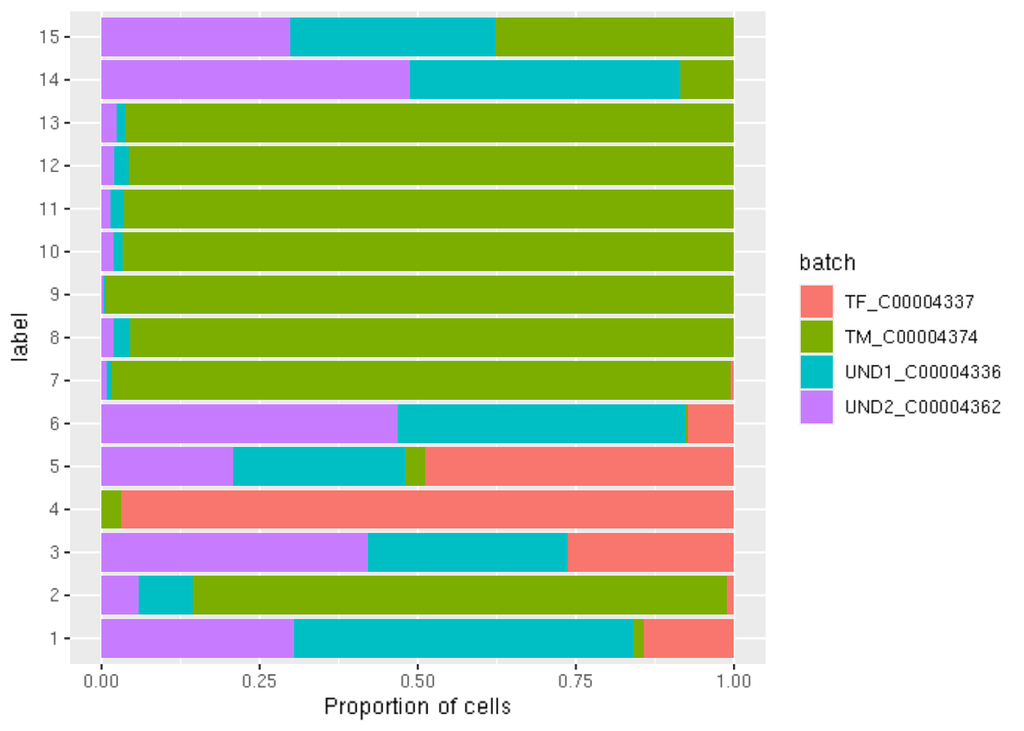

```r
meta_df = as.data.frame(colData(merged.sex.sce))

sample_tally =
  meta_df %>%
  mutate(label = as.factor(label),
         batch = as.factor(batch)) %>%
  group_by(label, batch, .drop = FALSE) %>%
  tally()

ggplot(sample_tally, aes(fill=batch, y=label, x=n)) +
    geom_bar(position="fill", stat="identity") +
    xlab("Proportion of cells")
```

```r
# make cds for plotting with monocle
all.sex.dec <- lapply(all.sex.sce, modelGeneVar)
# integration
# Intersecting the common genes.
universe <- Reduce(intersect, lapply(all.sex.sce, rownames))
all.sex.sce2 <- lapply(all.sex.sce, "[", i=universe,)
all.sex.dec2 <- lapply(all.sex.dec, "[", i=universe,)

all.sex.sce2[["TM_C00004374"]]@colData$cluster="noclust"

combined.sex.sce <- do.call(cbind, all.sex.sce2)
```

```r
merged.sex.cds <- new_cell_data_set(counts(combined.sex.sce),
                                cell_metadata = merged.sex.sce@colData)

reducedDims(merged.sex.cds)$tSNE <- reducedDims(merged.sex.sce)$TSNE
rowData(merged.sex.cds)$gene_short_name = row.names(merged.sex.cds)

saveRDS(merged.sex.cds, file = paste0(results_dir, "/no.support.merged.sex.cds.Rds"))
```

## Cluster enriched genes

This table contains the top ~100 cluster enriched genes for each cluster. All of the cluster enriched genes are saved in `sex_scatter_cluster_marker_genes.csv`. The markers can help us map a cluster to a cell type.

In this case, genes in each cluster were compared to genes in every other cluster in a pairwise manner, and the p.values and logFCs of those comparisons have been summarized for ease of interpretation.

**Column descriptions**

- `cluster`: The cluster corresponding to the enriched genes.
- `Gene`: The enriched gene
- `p.value`: The combined p-value across all pairwise comparisons.
- `FDR`: The BH-adjusted p-value for each gene.
- `summary.logFC`: This contains the summary effect size, obtained by combining effect sizes from all pairwise comparison into a single value.
- `WangGeneID`: BLAST equivalent gene name dervived by Wang et al, 2024
- `description`: Gene description

```r
scatter_markers = findMarkers(combined.sex.sce,
                              merged.sex.sce$label,
                              test.type="t",
                              block=combined.sex.sce$sample,
                              direction="up",
                              pval.type="some")

saveRDS(scatter_markers, file= paste0(results_dir, "/no.support_sex_scatter_markers.Rds"))
```

```r
scatter_markers = readRDS(paste0(results_dir, "/no.support_sex_scatter_markers.Rds"))

scatter_summary = list()

for (i in 1:length(scatter_markers)){

scatter_markers[[i]]$cluster = i
scatter_markers[[i]]$Gene = rownames(scatter_markers[[i]])
scatter_summary[[i]] =
  as.data.frame(scatter_markers[[i]]) %>%
  select(cluster, Gene, p.value, FDR, summary.logFC)

}

scatter_markers_df =
  do.call(rbind, scatter_summary) %>%
  left_join(gene_description, by="Gene") %>%
  mutate(cluster = paste0("cluster_",cluster)) %>%
  filter(FDR < .01)

write.csv(scatter_markers_df, file = paste0(results_dir, "/no.support_sex_scatter_cluster_marker_genes.csv"))

scatter_markers_top100 =
  scatter_markers_df %>%
  group_by(cluster) %>%
  slice_min(FDR, n = 100, with_ties=TRUE) %>%
  mutate(p.value = formatC(signif(p.value, digits = 3)),
         FDR = formatC(signif(FDR, digits = 3)),
         summary.logFC = round(summary.logFC, digits = 3))

datatable(scatter_markers_top100, filter = "top", rownames = FALSE)
```

| cluster | Gene | p.value | FDR | summary.logFC | WangGeneID | description |
| --- | --- | --- | --- | --- | --- | --- |
| cluster_1 | LOC116947140 | 4.11e-106 | 9.04e-102 | 3.164 | S100A1-7 | protein S100-A1-like |
| cluster_1 | LOC116947083 | 8.34e-100 | 9.16e-96 | 3.319 | S100A1-3 | protein S100-A1-like |
| cluster_1 | LOC116956112 | 1.01e-97 | 7.41e-94 | 3.171 | CUZD1.15 | CUB and zona pellucida-like domain-containing protein 1 |
| cluster_1 | LOC116947151 | 1.02e-94 | 5.61e-91 | 3.723 | S100A1-13 | protein S100-A1-like |
| cluster_1 | LOC116952630 | 2.89e-94 | 1.27e-90 | 3.818 | S100A1-22 | protein S100-A1-like |
| cluster_1 | LOC116945224 | 4.69e-94 | 1.72e-90 | 3.086 | EEF1A1 | elongation factor 1-alpha 1-like |
| cluster_1 | LOC116945977 | 6.91e-90 | 2.17e-86 | 4.39 | GP2 | pancreatic secretory granule membrane major glycoprotein GP2-like |
| cluster_1 | LOC116956102 | 1.29e-89 | 3.54e-86 | 3.565 | CUZD1.6 | CUB and zona pellucida-like domain-containing protein 1 |
| cluster_1 | LOC116947142 | 2.48e-87 | 6.05e-84 | 3.197 | S100A1-9 | protein S100-A1-like |
| cluster_1 | LOC116947082 | 8.3e-86 | 1.82e-82 | 3.872 | S100A1-2 | protein S100-A1-like, transcript variant X2 |

[output cut: 1491 more lines]

## Comparison with known markers

We’ll check for the significance of the overlap between the top 100 cluster enriched genes and the supplied known cell-type markers. In the plot below, the rows represent cell types with know marker genes, and the columns represent the cell clusters. The number in each box is the number of genes shared between the top 100 cluster enriched genes for the specified clusters and the specified known cell-type markers. Each box is colored by the significance of the overlap ($-log10(FDR)$). Significant overlaps may signify that the cells in the cluster belong to the specified cell type.

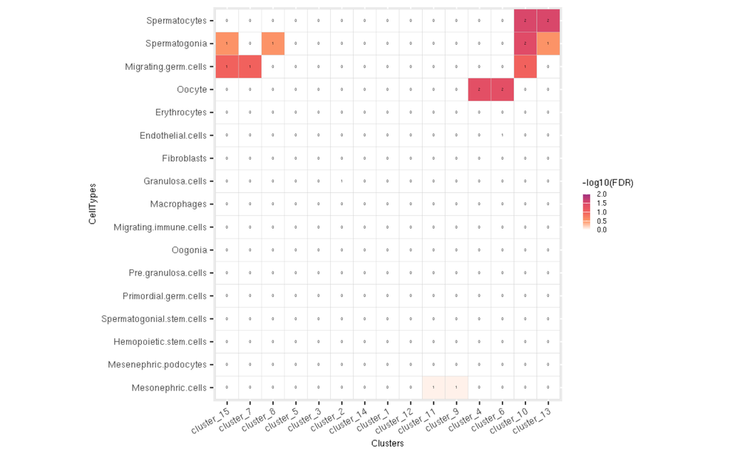

```r
marker_test_genes =
  scatter_markers_top100 %>%
  select(Gene, cluster)

cluster_ol =  phyperOverlapSets(chung_davidson_cell_type_markers,
                                marker_test_genes, length(merged.sex.sce))

shared_gene_description =
  gene_description %>%
  dplyr::rename(SharedGene = "Gene")

cluster_ol$intersecting.genes =
  cluster_ol$intersecting.genes %>%
  left_join(shared_gene_description, by="SharedGene")

write.csv(cluster_ol$intersecting.genes, file = paste0(results_dir, "/no.support_sex_scatter_cluster_marker_gene_overlaps.csv"), row.names = FALSE)

scores = cluster_ol$pval.scores

scores =
  scores %>%
  dplyr::rename(CellTypes = "Group1",
         Clusters = "Group2") %>%
  group_by(CellTypes) %>%
    mutate(FDR = p.adjust(Pval, "BH"))

#scores$FDR[scores$FDR > .01] = 1

FDR_wide <-
  scores %>%
  mutate(logFDR = -log10(FDR)) %>%
  tidyr::pivot_wider(id_cols = CellTypes,
                    names_from = Clusters,
                    values_from=logFDR)

CellTypes = FDR_wide$CellTypes
FDR_wide$CellTypes = NULL

FDR_wide = as.matrix(FDR_wide)
rownames(FDR_wide) = CellTypes

ord_row <- hclust( dist(FDR_wide), method = "ward.D" )$order
ord_col <- hclust( dist(t(FDR_wide)), method = "ward.D" )$order

scores$CellTypes = factor(scores$CellTypes, levels = rownames(FDR_wide)[ord_row])
scores$Clusters = factor(scores$Clusters, levels = colnames(FDR_wide)[ord_col])

plot1 =
    ggplot(scores,
           aes(Clusters, CellTypes)) +
           geom_tile(aes(fill = -log10(FDR)),
                     color = "light gray") +
        #Creating legend
        guides(fill=guide_colorbar(title = "-log10(FDR)",
                                   barheight = 10,
                                   barwidth = 2,
                                   default.unit = "mm")) +
        #Creating color range
        scale_fill_gradientn(colors=c("white",
                                      "#fd9668",
                                      "#f1605d",
                                      "#de4968",
                                      "#9e2f7f"),
                             guide="colorbar",
                             limits = c(0, ceiling(-log10(min(scores$FDR))))
                             ) +
        #Rotating labels
         theme(axis.text.x = element_text(angle = 30,
                                          hjust = 1,vjust=1),
               ) +
        theme(text = element_text(size = 7),
              axis.text = element_text(size = 7)) +
        geom_text(aes(label = nSharedGenes), size = 1) +
        coord_fixed()

plot1
```

```r
ggsave(plot1, file = paste0(results_dir, "/no.support_sex_scatter_cluster_overlap_heatmap.png"))
```

## Gene ontology of top 100 scatter cluster enriched genes

To help annotate cell type clusters, we can check for enriched gene ontology categories among cell-type enriched genes.

**Columns**

- `GOID`: Gene ontology ID
- `GOName`: Gene ontology name
- `nGOTermGenes`: Number of genes assigned to GO term
- `Clusters`: Cluster
- `nClusterEnrichedGenes`: Number of cluster enriched genes
- `nSharedGenes`: Number of shared genes between the GO term and cluster enriched genes
- `Pval`: p-value
- `FDR`: p-value corrected for multiple comparisons

```r
gaf = read.delim("/mnt/research/bioinformaticsCore/shared/Genomes/Petromyzon_marinus/GCF_010993605.1_kPetMar1.pri_gene_ontology.gaf", header=F, comment = "!")

gaf <-
  gaf %>%
  filter(!grepl("NOT", V4)) %>%
  dplyr::select(V3, V5) %>%
  dplyr::rename(GOID = "V5",
                Gene = "V3") %>%
  distinct()

keep_go =
  gaf %>%
  group_by(GOID) %>%
  tally() %>%
  filter(n > 10,
         n < 200) %>%
  pull(GOID)

gaf =
  gaf %>%
  filter(GOID %in% keep_go)

go_names = read.delim("/mnt/research/bioinformaticsCore/shared/Genomes/Petromyzon_marinus/GOs_names.txt", header = F)
colnames(go_names) = c("GOID", "GOName")

go_ol =  phyperOverlapSets(gaf,
                           marker_test_genes, length(merged.sex.sce))

shared_gene_description =
  gene_description %>%
  dplyr::rename(SharedGene = "Gene")

go_ol$intersecting.genes =
  go_ol$intersecting.genes %>%
  left_join(shared_gene_description, by="SharedGene")

write.csv(go_ol$intersecting.genes, file = paste0(results_dir, "/no.support_sex_scatter_cluster_marker_gene_GO_overlaps.csv"), row.names = FALSE)

scores = go_ol$pval.scores

scores =
  scores %>%
  dplyr::rename(GOID = "Group1",
                Clusters = "Group2",
                nGOTermGenes = "nGroup1",
                nClusterEnrichedGenes = "nGroup2") %>%
  group_by(Clusters) %>%
    mutate(FDR = p.adjust(Pval, "BH")) %>%
  select(-Enrichment)

scores =
  left_join(go_names, scores, by="GOID") %>%
  filter(!is.na(nGOTermGenes)) %>%
  filter(nSharedGenes > 0)

write.csv(scores, file = paste0(results_dir, "/no.support_sex_scatter_cluster_marker_gene_GO_pvals.csv"), row.names = FALSE)

datatable(scores, filter = "top", rownames = FALSE)
```

| GOID | GOName | nGOTermGenes | Clusters | nClusterEnrichedGenes | nSharedGenes | Pval | FDR |
| --- | --- | --- | --- | --- | --- | --- | --- |
| GO:0000027 | ribosomal large subunit assembly | 16 | cluster_10 | 100 | 2 | 0.03960594588450352 | 1 |
| GO:0000027 | ribosomal large subunit assembly | 16 | cluster_11 | 100 | 2 | 0.03960594588450352 | 1 |
| GO:0000027 | ribosomal large subunit assembly | 16 | cluster_12 | 100 | 4 | 0.0002279454850028617 | 0.0241907145959287 |
| GO:0000027 | ribosomal large subunit assembly | 16 | cluster_13 | 100 | 2 | 0.03960594588450352 | 1 |
| GO:0000027 | ribosomal large subunit assembly | 16 | cluster_15 | 101 | 1 | 0.2789197086820161 | 1 |
| GO:0000027 | ribosomal large subunit assembly | 16 | cluster_8 | 100 | 2 | 0.03960594588450352 | 1 |
| GO:0000027 | ribosomal large subunit assembly | 16 | cluster_9 | 100 | 3 | 0.003597658985165955 | 0.381801559800737 |
| GO:0000028 | ribosomal small subunit assembly | 15 | cluster_10 | 100 | 2 | 0.03510491002208635 | 1 |
| GO:0000028 | ribosomal small subunit assembly | 15 | cluster_11 | 100 | 3 | 0.002965837703885376 | 0.3597137443712406 |
| GO:0000028 | ribosomal small subunit assembly | 15 | cluster_12 | 100 | 5 | 7.416303475075153e-06 | 0.000899491664334115 |

[output cut: 595 more lines]

# Sex cell developement trajectory analysis

## Trajectory plotted in TSNE space

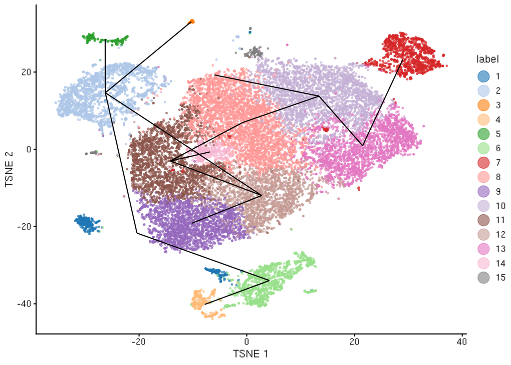

```r
set.seed(1)
by.cluster <- aggregateAcrossCells(merged.sex.sce,
                                   ids=colLabels(merged.sex.sce), use.assay.type = "reconstructed")

centroids <- reducedDim(by.cluster, "corrected")

mst <- createClusterMST(centroids, clusters=NULL)

line.data <- reportEdges(by.cluster, mst=mst, clusters=NULL, use.dimred="TSNE")

plotTSNE(merged.sex.sce, colour_by="label", point_size = .5) +
    geom_line(data=line.data, mapping=aes(x=TSNE1, y=TSNE2, group=edge)) +
  guides(color = guide_legend(override.aes = list(size=5)))
```

## Trajectory plotted in batch corrected gene expression space

It’s hard to interpret this in TSNE space, so we’ll plot in batch corrected expression space instead because the clusters and trajectory analysis were actually calculated in batch corrected expression space.

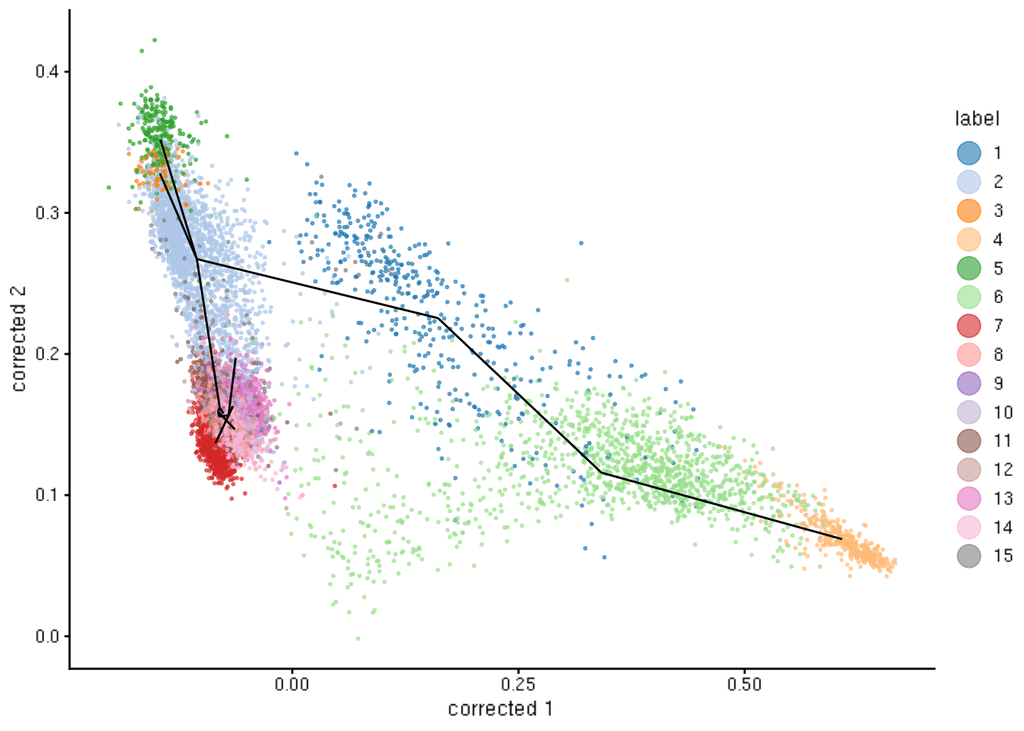

```r
line.data_corrected <- reportEdges(by.cluster, mst=mst, clusters=NULL, use.dimred="corrected")

plotReducedDim(merged.sex.sce, colour_by="label", dimred = "corrected", point_size = .4) +
    geom_line(data=line.data_corrected, mapping=aes(x=dim1, y=dim2, group=edge)) + guides(color = guide_legend(override.aes = list(size=5)))
```

```r
set.seed(1)
pseudo <- quickPseudotime(merged.sex.sce, use.dimred="corrected", outgroup=FALSE, start = 1)
saveRDS(pseudo, file=paste0(results_dir, "/no.support_sex_pseudo.Rds"))
```

## Trajectory plotted with each cluster as a node

Simplify even further.

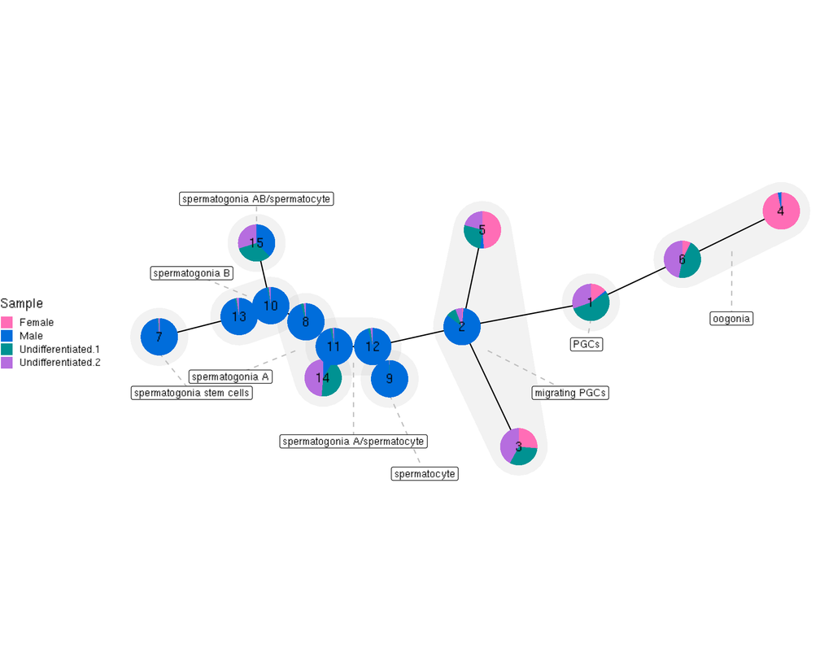

```r
pseudo = readRDS(paste0(results_dir, "/no.support_sex_pseudo.Rds"))

library(ggforce)
library(ggraph)
library(tidygraph)
library(scatterpie)
library(ggrepel)

gr <- as_tbl_graph(pseudo$mst)

node_meta =
  sample_tally %>%
  mutate(batch = case_when(
    batch == "TF_C00004337" ~ "Female",
    batch == "TM_C00004374" ~ "Male",
    batch == "UND1_C00004336" ~ "Undifferentiated.1",
    batch == "UND2_C00004362" ~ "Undifferentiated.2"
  )) %>%
  tidyr::pivot_wider(names_from = batch, values_from = n) %>%
  mutate(totalCells = sum(Female,
                          Male,
                          Undifferentiated.1,
                          Undifferentiated.2,
                          na.rm = TRUE)) %>%
  dplyr::rename(name = "label")

group_vec =
  c("PGCs",
    "migrating PGCs",
    "migrating PGCs",
    "oogonia",
    "migrating PGCs",
    "oogonia",
    "spermatogonia stem cells",
    "spermatogonia A",
    "spermatocyte",
    "spermatogonia B",
    "spermatogonia A/spermatocyte",
    "spermatogonia A/spermatocyte",
    "spermatogonia B",
    "spermatogonia A",
    "spermatogonia AB/spermatocyte"
    )

node_meta$CellType = group_vec

gr =
  gr %>%
  activate(nodes) %>%
  left_join(node_meta) %>%
  arrange(desc(totalCells))


layout_data <- create_layout(gr, layout = 'stress')

hull_data <- layout_data %>%
  group_by(CellType) %>%
  slice(chull(x, y))

hull_centroids =
  hull_data %>%
  group_by(CellType) %>%
  summarise(hull_x = mean(x),
            hull_y = mean(y))

label_positions <- tibble(
  CellType = c(
    "migrating PGCs",
    "oogonia",
    "PGCs",
    "spermatocyte",
    "spermatogonia A",
    "spermatogonia A/spermatocyte",
    "spermatogonia AB/spermatocyte",
    "spermatogonia B",
    "spermatogonia stem cells"
  ),
  label_x = c(
    -0.15,   # migrating male GC - move right below point 3
    0.348,   # oogonia - keep upper right
    -0.1,   # primordial GC - move slightly right
    -0.60,   # spermatocyte - move right to avoid overlap
    -1.2,   # spermatogonia A - move left of cluster
    -0.82,   # spermatogonia A/spermatocyte - below cluster
    -1.12,   # spermatogonia AB/spermatocyte - keep above point 15
    -1.32,   # spermatogonia B - move right to avoid stem cells label
    -1.32    # spermatogonia stem cells - keep left
  ),
  label_y = c(
    -0.35,   # migrating male GC - below point 3
    -0.12,   # oogonia - above cluster
    -0.20,   # primordial GC - at current height
    -0.60,   # spermatocyte - below point 9
    -0.30,   # spermatogonia A - left of points 8, 14
    -0.50,   # spermatogonia A/spermatocyte - below points 11, 12
    0.25,   # spermatogonia AB/spermatocyte - above point 15
    0.02,   # spermatogonia B - between clusters
    -0.35    # spermatogonia stem cells - below point 7
  )
)

label_positions = left_join(label_positions, hull_centroids)
label_positions[5,4] = -1 # spermatogonia A segement end
label_positions[5,5] = -.17 # spermatogonia A segement end
label_positions[8,4] = -1.15
label_positions[8,5] = 0
label_positions[7,5] = .2


gr_plot =
  ggraph(gr, "stress") +
  geom_shape(
    data = hull_data,
    aes(x, y,
        fill = CellType,
        fill = after_scale("gray"),
        group = CellType),
    expand = 0.04,
    radius = 0.04,
    show.legend = FALSE,
    alpha = .2
  ) +
  # Hulls mapped to CellType, but all gray + no legend
  geom_segment(data = label_positions,
               aes(x = hull_x, y = hull_y - .05,
                   xend = label_x, yend = label_y),
               color = "gray",
               linetype="dashed",
               linewidth = 0.5,
               arrow = NULL) +
  geom_edge_link() +
  # Scatter pies with manual color scale + legend
  geom_label(data = label_positions,
             aes(x = label_x, y = label_y, label = CellType),
             size = 3,
             label.padding = unit(0.25, "lines")) +
  geom_scatterpie(
    aes(x, y),
    cols = c("Female", "Male", "Undifferentiated.1", "Undifferentiated.2"),
    data = layout_data,
    colour = NA,
    pie_scale = 1.5
  ) +
  scale_fill_manual(
    name = "Sample",
    values = c(
      "Female" = "#FF6DB6",
      "Male" = "#006ddb",
      "Undifferentiated.1" = "#009292",
      "Undifferentiated.2" = "#b66ddf"
    )
  ) +
  guides(fill = guide_legend(keywidth = .8,
                             keyheight =.8)) +
  geom_node_text(aes(label = name), color = "black") +
  theme_void() +
  theme(
    legend.position = "left",
    legend.justification = "center",  # left-align content inside legend box
    legend.box.just = "center"           # align legend box in layout
  )

gr_plot + coord_fixed()
```

Plot pseudotime

```r
common.pseudo <- averagePseudotime(pseudo$ordering)
merged.sex.sce$Pseudotime <- common.pseudo

# pseudo_plot =
#   plotTSNE(merged.sex.sce, colour_by="Pseudotime",
#         text_by="label", text_colour="red",  point_size = .5, text_size = 3) +
#     geom_line(data=line.data, mapping=aes(x=TSNE1, y=TSNE2, group=edge))
#
# pseudo_plot
```

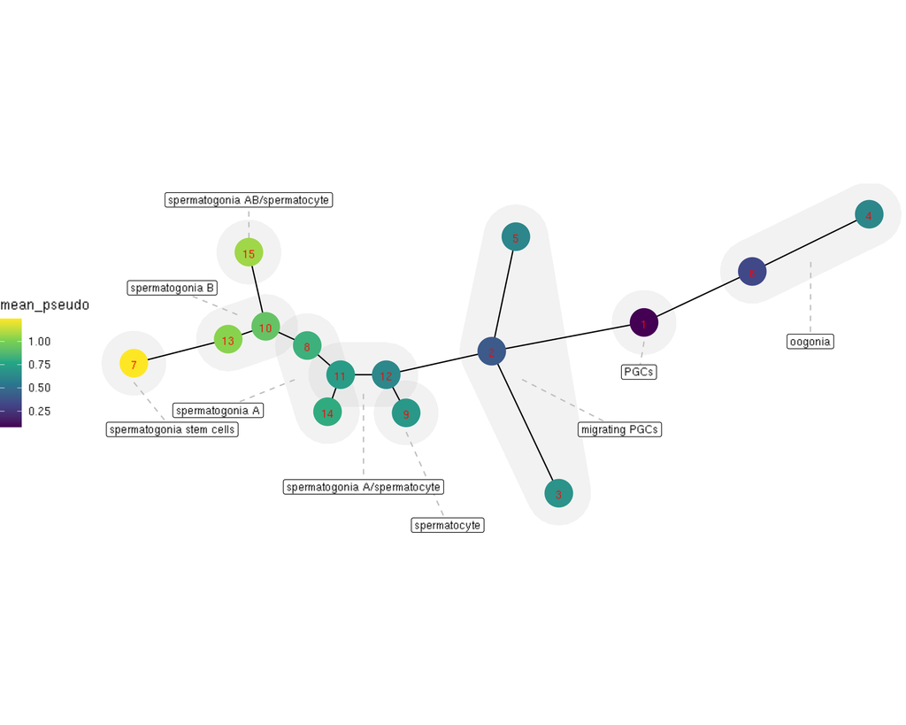

```r
mean_pseudo=
  as.data.frame(colData(merged.sex.sce)) %>%
  group_by(label) %>%
  summarise(mean_pseudo = mean(Pseudotime)) %>%
  dplyr::rename(name = "label")

gr =
  gr %>%
  activate(nodes) %>%
  left_join(mean_pseudo)

gr_pseudo =
  ggraph(gr, "stress") +
  geom_shape(
    data = hull_data,
    aes(x, y,
        fill = CellType,
        fill = after_scale("gray"),
        group = CellType),
    expand = 0.04,
    radius = 0.04,
    show.legend = FALSE,
    alpha = .2
  ) +
  geom_segment(data = label_positions,
               aes(x = hull_x, y = hull_y - .05,
                   xend = label_x, yend = label_y),
               color = "gray",
               linetype = "dashed",
               size = 0.5,
               arrow = NULL) +
  geom_edge_link() +
  geom_node_point(aes(color = mean_pseudo), size = 10) +  # Color nodes by pseudotime
  scale_color_viridis_c(option = "viridis") +  # Continuous viridis scale
  geom_node_text(aes(label = name), vjust = .75, size = 3, color = "red") +
  geom_label(data = label_positions,
             aes(x = label_x, y = label_y, label = CellType),
             size = 3,
             label.padding = unit(0.25, "lines")) +
  coord_fixed() +
  theme_void() +
  theme(
    legend.position = "left",
    legend.justification = "center",  # left-align content inside legend box
    legend.box.just = "center"           # align legend box in layout
  )

gr_pseudo
```